# Ghost introgression investigation

Devon DeRaad

4/15/2021

```r
library(vcfR)
library(adegenet)
```

```r
library(ggplot2)
library(introgress)
library(StAMPP)
library(gridExtra)
#load data
vcf<-read.vcfR("/Users/devder/Desktop/parrots/la.parrots/parrotsnpsunfiltered.vcf")
```

[output not shown]

```r
#convert vcfr to genlight
gen<- vcfR2genlight(vcf)
#read in locality info for samples
locs<-read.table("~/Desktop/parrots/la.parrots/parrotsamples.txt", header=T, sep="\t")
colnames(locs)<-c("id","location","tiss")
locs$group<-as.character(locs$location)
locs$group[c(1,2)]<-"LA lilac crowns"
locs$group[3:6]<-"Mexico lilac crowns"
locs$group[27:30]<-"Mexico red crowns"
locs$group[c(24,26)]<-"RC/LC hybrids"
locs$group[c(8,11,22,20,18,23,14)]<-"ghost introgressed LA RCs"
locs$group[locs$group == "CA"]<-"LA red crowns"
gen@ind.names
```

```
##  [1] "AmafinB646"     "AmafinB714"     "AmafinMLZ12743" "AmafinMLZ25447"
##  [5] "AmafinMLZ46005" "AmafinMLZ54378" "AmavirB564"     "AmavirB645"
##  [9] "AmavirB715"     "AmavirB716"     "AmavirB717"     "AmavirB718"
## [13] "AmavirB720"     "AmavirB721"     "AmavirB724"     "AmavirB725"
## [17] "AmavirB726"     "AmavirB727"     "AmavirB728"     "AmavirB729"
## [21] "AmavirB730"     "AmavirB731"     "AmavirB734"     "AmavirB755"
## [25] "AmavirLA7603"   "AmavirLA8540"   "AmavirMLZ32264" "AmavirMLZ39529"
## [29] "AmavirMLZ39531" "AmavirMLZ48335"
```

```r
#check that sampling IDs in text file match sample IDs in the vcf
gen@ind.names == locs$id
```

```
##  [1] TRUE TRUE TRUE TRUE TRUE TRUE TRUE TRUE TRUE TRUE TRUE TRUE TRUE TRUE TRUE
## [16] TRUE TRUE TRUE TRUE TRUE TRUE TRUE TRUE TRUE TRUE TRUE TRUE TRUE TRUE TRUE
```

```r
#make vector to store missing proportion of each SNP
miss<-c()
gen.mat<-t(as.matrix(gen))
for (i in 1:nrow(gen.mat)){
  miss[i]<-sum(is.na(gen.mat[i,]))/ncol(gen.mat)
}

#make dataframes at various missing data cutoffs
gen.60<-gen[,miss < .4]
gen.80<-gen[,miss < .2]
gen.100<-gen[,miss == 0]
gen.60
```

```
##  /// GENLIGHT OBJECT /////////
##
##  // 30 genotypes,  8,508 binary SNPs, size: 1.2 Mb
##  51652 (20.24 %) missing data
##
##  // Basic content
##    @gen: list of 30 SNPbin
##
##  // Optional content
##    @ind.names:  30 individual labels
##    @loc.names:  8508 locus labels
##    @chromosome: factor storing chromosomes of the SNPs
##    @position: integer storing positions of the SNPs
##    @other: a list containing: elements without names
```

```r
gen.100
```

```
##  /// GENLIGHT OBJECT /////////
##
##  // 30 genotypes,  1,070 binary SNPs, size: 399.7 Kb
##  0 (0 %) missing data
##
##  // Basic content
##    @gen: list of 30 SNPbin
##
##  // Optional content
##    @ind.names:  30 individual labels
##    @loc.names:  1070 locus labels
##    @chromosome: factor storing chromosomes of the SNPs
##    @position: integer storing positions of the SNPs
##    @other: a list containing: elements without names
```

```r
#make dataframe with only Red crowned parrots
rc.80<-gen.80[c(7:23,25,27:30),]
rc.100<-gen.100[c(7:23,25,27:30),]
#make red crowned locs file
rc<-locs[c(7:23,25,27:30),]
```

# make a PCA with only Red-crowned parrots to identify this potential "ghost introgression" pattern where 7 LA red-crowned samples are united as a separate clade from the rest of the sampled red-crowns

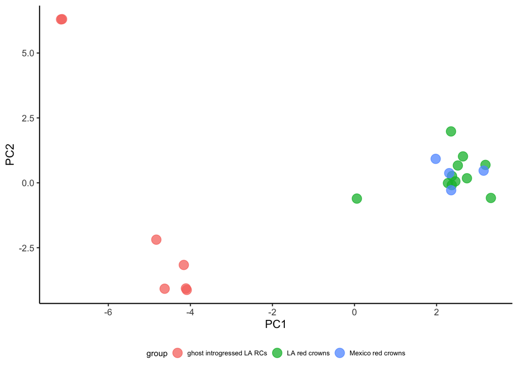

```r
#make pca
pca<-glPca(rc.80, nf=6)

#pull pca scores out of df
pca.scores<-as.data.frame(pca$scores)
pca.scores$group<-rc$group

#ggplot color by species
ggplot(pca.scores, aes(x=PC1, y=PC2, color=group)) +
  geom_point(cex = 4, alpha=.75)+
  theme_classic()+
  theme(legend.position = "bottom", legend.key.size = unit(0, 'cm'),
        legend.title = element_text(size=8), legend.text = element_text(size=6.5))
```

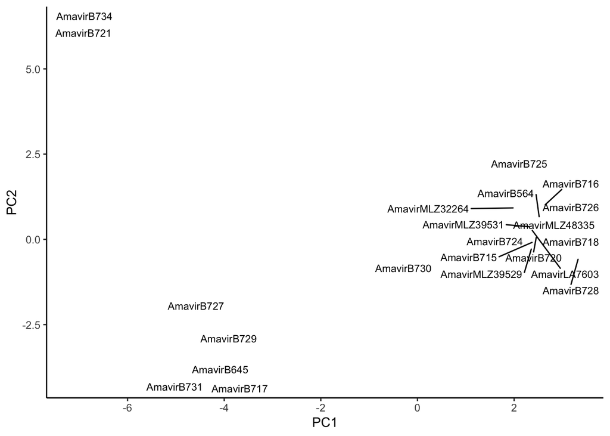

```r
#plot pca with sample names
ggplot(pca.scores, aes(x=PC1, y=PC2))+
  ggrepel::geom_text_repel(label=rc$id, cex=3)+
  theme_classic()
```

# plot sequential PCAs using only the top loading SNPs, and dropping the top loading SNPs, in order to identify how many SNPs are driving the pattern of relatedness we see.

```
## [1] "outliers > 3 standard deviations from mean PC1 loading"
##        chrom pos  PC1loading
## 3   uce-3160  68 -0.05559085
## 4   uce-3160 146 -0.06037380
## 5   uce-3160 149 -0.06037380
## 6   uce-3160 184 -0.06060056
## 173 uce-6730  49 -0.06060056
## 174 uce-6730  81 -0.06172817
##
## uce-1131 uce-1201 uce-1533  uce-157 uce-1582 uce-1590 uce-1603 uce-1660
##        7        1        1        8        4        5        1        9
## uce-1685 uce-1970 uce-2138 uce-2202 uce-2361 uce-2752 uce-3160  uce-317
##        6        3        1        5        1        1        4       11
## uce-3185 uce-3469 uce-3660 uce-3810 uce-3917 uce-3990 uce-4363 uce-4615
##        3        3        1        1        1        5        1        1
## uce-4970 uce-5174 uce-5190 uce-5495  uce-550 uce-5690  uce-591 uce-5975
##        4        1        5        2        4        1       11        1
##    uce-6 uce-6126 uce-6164   uce-63 uce-6512 uce-6535 uce-6730 uce-6739
##        1        5        1        1        1        1        3        5
## uce-6882 uce-6885 uce-7014 uce-7037 uce-7053  uce-715 uce-7319 uce-7340
##        5       12        5        2        1        4        2        1
## uce-7414 uce-7761 uce-7790  uce-791 uce-7914 uce-7996
##        1        9        4        1        5        4
```

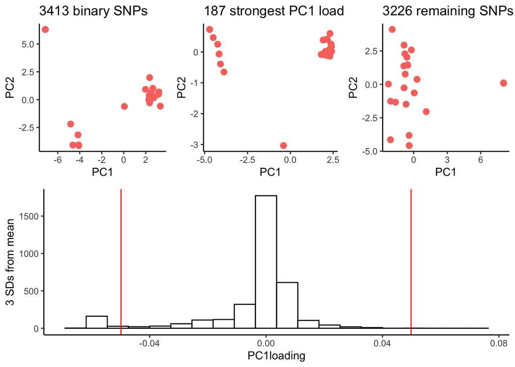

```
## [1] "outliers > 3.5 standard deviations from mean PC1 loading"
##        chrom pos  PC1loading
## 4   uce-3160 146 -0.06037380
## 5   uce-3160 149 -0.06037380
## 6   uce-3160 184 -0.06060056
## 173 uce-6730  49 -0.06060056
## 174 uce-6730  81 -0.06172817
## 175 uce-6730  89 -0.06172817
##
## uce-1131 uce-1533  uce-157 uce-1582 uce-1660 uce-1970 uce-2138 uce-2202
##        7        1        6        4        7        3        1        4
## uce-2361 uce-3160  uce-317 uce-3185 uce-3469 uce-3660 uce-3810 uce-3917
##        1        3        8        2        2        1        1        1
## uce-3990 uce-4363 uce-4970 uce-5174 uce-5190 uce-5495  uce-550 uce-5690
##        4        1        4        1        5        1        4        1
##  uce-591 uce-5975    uce-6 uce-6126   uce-63 uce-6512 uce-6730 uce-6739
##        8        1        1        4        1        1        3        1
## uce-6882 uce-6885 uce-7014 uce-7037 uce-7053  uce-715 uce-7319 uce-7340
##        3       11        5        2        1        2        1        1
## uce-7414 uce-7761 uce-7790  uce-791 uce-7914 uce-7996
##        1        8        4        1        5        3
```

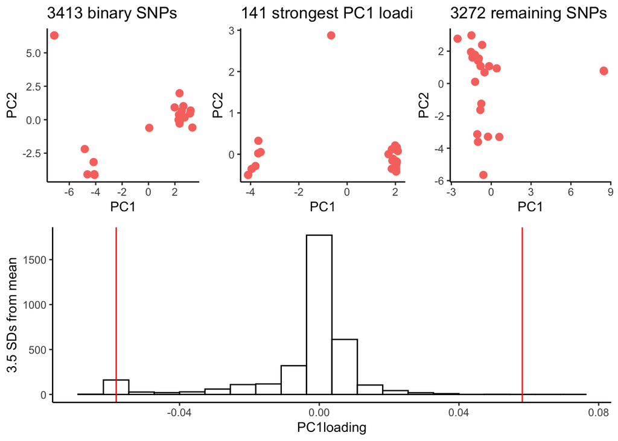

```
## [1] "outliers > 3.6 standard deviations from mean PC1 loading"
##        chrom pos  PC1loading
## 4   uce-3160 146 -0.06037380
## 5   uce-3160 149 -0.06037380
## 6   uce-3160 184 -0.06060056
## 173 uce-6730  49 -0.06060056
## 174 uce-6730  81 -0.06172817
## 175 uce-6730  89 -0.06172817
##
## uce-1131 uce-1533  uce-157 uce-1582 uce-1660 uce-1970 uce-2202 uce-2361
##        6        1        6        4        7        3        2        1
## uce-3160  uce-317 uce-3185 uce-3660 uce-3810 uce-3990 uce-4970 uce-5174
##        3        8        2        1        1        3        2        1
## uce-5190 uce-5495  uce-550  uce-591    uce-6 uce-6126 uce-6512 uce-6730
##        5        1        4        7        1        3        1        3
## uce-6739 uce-6882 uce-6885 uce-7014 uce-7037 uce-7053  uce-715 uce-7340
##        1        3        8        5        1        1        1        1
## uce-7414 uce-7761 uce-7790  uce-791 uce-7914 uce-7996
##        1        5        4        1        5        2
```

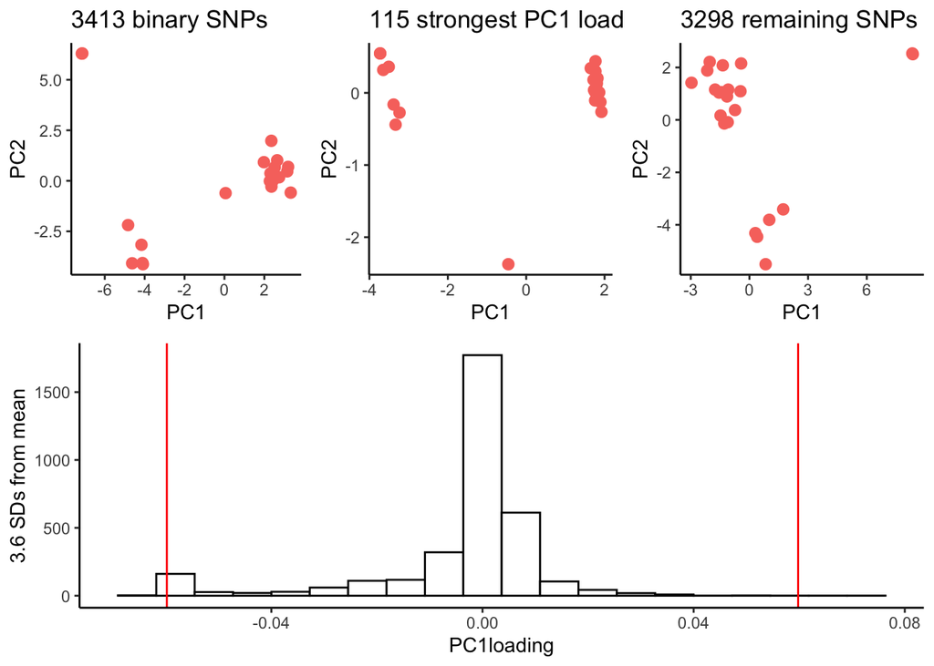

```r
#amongst Red-Crowned parrots we have this strange group from LA that clusters away from everything else
#investigate the SNPs driving this pattern
#store PC loadings
investigate.pca.outliers <- function(gen, std){
  genlight<-gen
  for (i in std){
    pca <- glPca(genlight, nf=10)
    df<-as.data.frame(cbind(as.character(genlight@chromosome), genlight@position, pca$loadings[,1]))
    colnames(df)<-c("chrom","pos","PC1loading")
    df$PC1loading<-as.numeric(as.character(df$PC1loading))
    hist<-ggplot(df, aes(x=PC1loading))+
      geom_histogram(color="black", fill="white", bins=20)+
      geom_vline(aes(xintercept=sd(PC1loading)*i), color = "red")+
      geom_vline(aes(xintercept=-sd(PC1loading)*i), color = "red")+
      theme_classic()+
      ylab(paste(i,"SDs from mean"))
    #list loading outliers
    print(paste("outliers >",i,"standard deviations from mean PC1 loading"))
    print(head(df[abs(df$PC1loading) > sd(df$PC1loading)*i,]))
    print(table(df$chrom[abs(df$PC1loading) > sd(df$PC1loading)*i])[table(df$chrom[abs(df$PC1loading) > sd(df$PC1loading)*i]) > 0])
    #pca1
    pca<- glPca(genlight, nf=10)
    pca.scores<-as.data.frame(pca$scores)
    #ggplot color by species
    pca.1<-ggplot(pca.scores, aes(x=PC1, y=PC2, col=as.factor(substr(genlight$ind.names, 1,3)))) +
      geom_point(cex = 2.5)+
      ggtitle(paste(ncol(genlight),"binary SNPs"))+
      theme_classic()+
      theme(legend.position = "none")
    #pca2
    pca<- glPca(genlight[,abs(df$PC1loading) > sd(df$PC1loading)*i], nf=10)
    pca.scores<-as.data.frame(pca$scores)
    #ggplot color by species
    pca.2<-ggplot(pca.scores, aes(x=PC1, y=PC2, col=as.factor(substr(genlight$ind.names, 1,3)))) +
      geom_point(cex = 2.5)+
      ggtitle(paste(ncol(genlight[,abs(df$PC1loading) > sd(df$PC1loading)*i]),"strongest PC1 loading SNPs"))+
      theme_classic()+
      theme(legend.position = "none")
    #pca3
    pca<- glPca(genlight[,!abs(df$PC1loading) > sd(df$PC1loading)*i], nf=10)
    pca.scores<-as.data.frame(pca$scores)
    #ggplot color by species
    pca.3<-ggplot(pca.scores, aes(x=PC1, y=PC2, col=as.factor(substr(genlight$ind.names, 1,3)))) +
      geom_point(cex = 2.5)+
      ggtitle(paste(ncol(genlight[,!abs(df$PC1loading) > sd(df$PC1loading)*i]),"remaining SNPs"))+
      theme_classic()+
      theme(legend.position = "none")
    #print together
    gl<-list(pca.1,pca.2,pca.3,hist)
    grid.arrange(grobs = gl,
                 widths = c(1,1,1),
                 layout_matrix = rbind(c(1,2,3),
                                       c(4,4,4)))
  }
}

investigate.pca.outliers(gen = rc.80, std = c(3,3.5,3.6))
```

# make a PCA including all samples, with only these 183 putatively introgressed SNPs driving the pattern of structure that separates the 7 LA red crowns from the rest of the red crowns

```r
#store PC1 axis loadings for each SNP
df<-as.data.frame(cbind(as.character(rc.80@chromosome), rc.80@position, pca$loadings[,1]))
colnames(df)<-c("chrom","pos","PC1loading")
df$PC1loading<-as.numeric(as.character(df$PC1loading))

#make hist of SNPs PC1
table(df$PC1loading < -.05)
```

```
##
## FALSE  TRUE
##  3230   183
```

```r
table(rc.80@chromosome == as.vector(df$chrom))
```

```
##
## TRUE
## 3413
```

```r
table(gen.80@loc.names == rc.80@loc.names)
```

```
##
## TRUE
## 3413
```

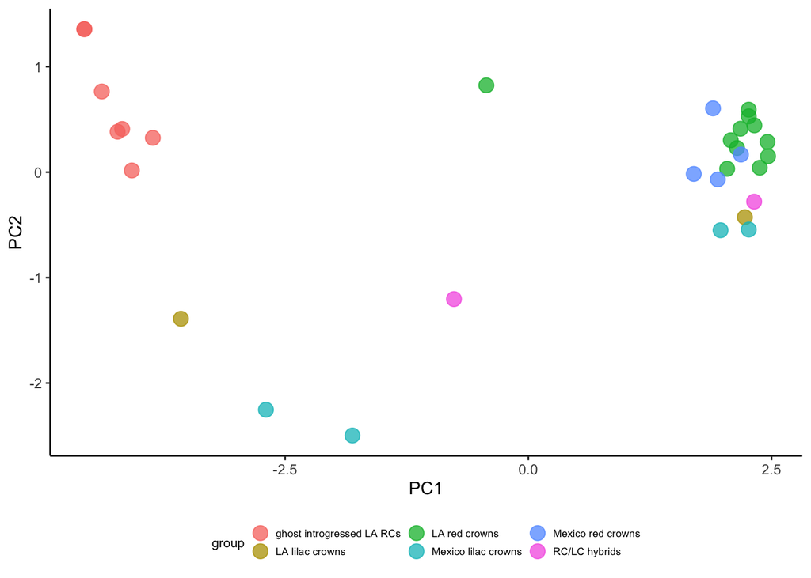

```r
#make a new genlight with only the 183 SNPs putatively driving the "ghost introgression" pattern
intro.loci<-gen.80[,df$PC1loading < -.05]

#make pca
pca<-glPca(intro.loci, nf=6)

#pull pca scores out of df
pca.scores<-as.data.frame(pca$scores)
pca.scores$group<-locs$group

#ggplot color by species
ggplot(pca.scores, aes(x=PC1, y=PC2, color=group)) +
  geom_point(cex = 4, alpha=.75)+
  theme_classic()+
  theme(legend.position = "bottom", legend.key.size = unit(0, 'cm'),
        legend.title = element_text(size=8), legend.text = element_text(size=6.5))
```

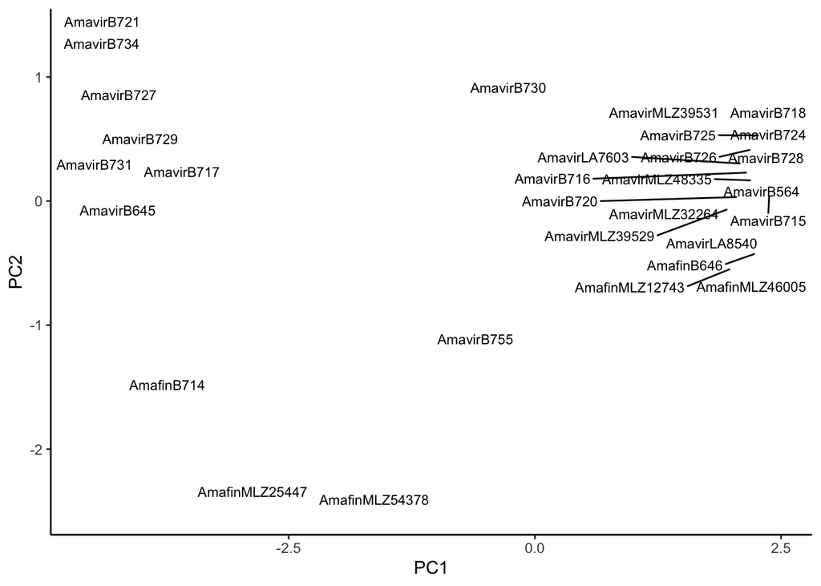

```r
#plot pca with sample names
ggplot(pca.scores, aes(x=PC1, y=PC2))+
  ggrepel::geom_text_repel(label=locs$id, cex=3)+
  theme_classic()
```